# Assignment 1

```r
library(tidyverse)
```

```r
MyData <- read.csv(file="distance.csv", header=TRUE, sep=",")
MyData
```

| distance | who |
| --- | --- |
| 250 or less | students |
| 250 or less | students |
| 250 or less | students |
| 250 or less | students |
| 250 or less | students |
| 250 or less | students |
| 250 or less | students |
| 250 or less | students |
| 250 or less | students |
| 250 or less | students |

[output cut: 990 more lines]

15,722 people responded to the survey since there are 15,722 rows in `MyData`.

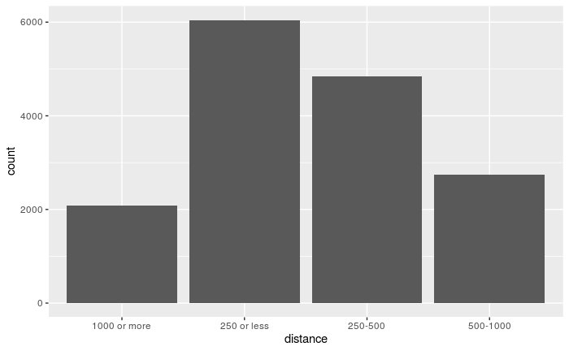

```r
ggplot(MyData, aes(x = distance)) + geom_bar()
```

- Bar chart for `MyData` since there is only 1 categorical variable.
- It’s clear that more people want to live closer to the universtiy they’re attending.

`distance` isn’t in order. It starts with the largest `distance` value then continues with the smallest. This happens because `distance` is probably alphabetically ordered where 1 comes before 2.

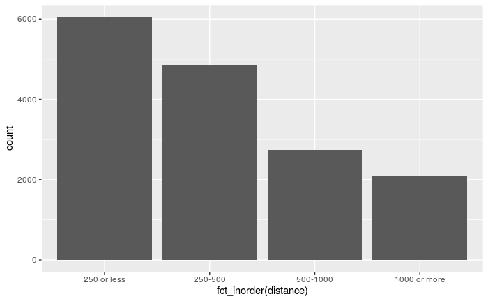

```r
ggplot(MyData, aes(x = fct_inorder(distance))) + geom_bar()
```

`distance` is in increasing order now which makes more sense.

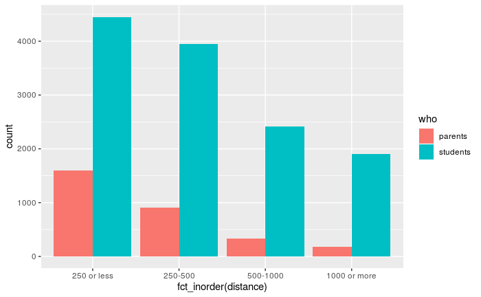

```r
ggplot(MyData, aes(x = fct_inorder(distance), fill = who)) + geom_bar(position = "dodge")
```

- Grouped bar chart for `MyData` since there are 2 categorical variables.
- It’s clear that the majority of students and parents of the students would like to live closer to the universtiy the students are going to attend.

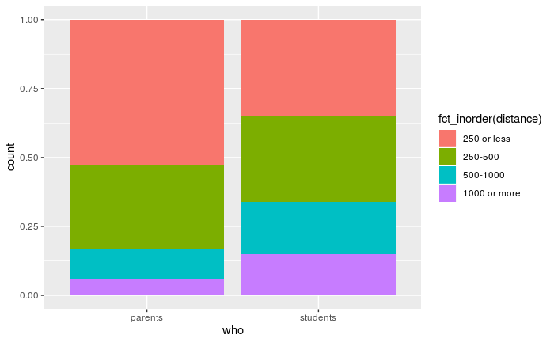

```r
ggplot(MyData, aes(x = who, fill = fct_inorder(distance))) + geom_bar(position = "fill")
```

The new grouped bar graph compares the preferences of students and parents on the x axis and shows the most popular choices for `distance` on the y axis. `distance` is also now differentiated by colour since it’s not seperated on the x axis anymore.